# Vignettes for lsurvROC

## Installation

```r
library(remotes)
remotes::install_github("Xiaona923/Longitudinal_Biomarker_ROC", force = TRUE)
library(lsurvROC)
```

## Introduction

We propose a flexible regression framework to evaluate the prognostic capability of longitudinal biomarker with survival outcome accounting for the covariate and biomaker measurement time. Here is an example using a simulated dataset to estimate the biomarker threshold at a specified specificity level along with the corresponding sensitivity, and to construct a covariate- and measurement time-specific ROC curve.

## Read in example data

```r
data("example_data")
```

## Estimate time-varying coefficients

- **dat.long**: long format data, each subject may have multiple biomarker records
- **dat.short**: short format data, each subject only has one record, including observed event time, event indicator, covariates (eg. Z, Zcont in this example)
- **cutoff.type.basis**: type of basis function to estimate biomarker threshold, (FP: Fractional polynomial, BS: B Splines, linear: linear basis)
- **sens.type.basis**: type of basis function to estimate sensitivity level, (FP: Fractional polynomial, BS: B Splines, linear: linear basis)
- **covariate1**: a vector of covariate names to estimate the biomarker threshold
- **covariate2**: a vector of covariate names to estimate the sensitivity level
- **tau**: target specificity level, could be a single value or a set of values between 0 and 1
- **time.window**: a time window for biomarker evaluation
- **monotone.method**: user specified method for monotonization
- **nResap**: number of perturbation resampling

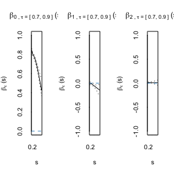

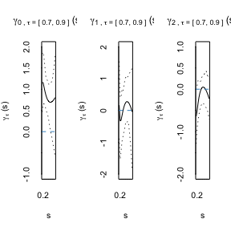

```r
res = lsurvROC(dat.long = example_data$data.long,
              dat.short = example_data$data.short,
              cutoff.type.basis = "FP",
              sens.type.basis = "FP",
              covariate1 = c("Z", "Zcont"),
              covariate2 = c("Z", "Zcont"),
              tau = c(0.7, 0.8, 0.9),
              time.window = 1,
              monotone.method = "both",
              nResap = 50,
              newdata = NULL
              )

par(mfrow=c(1,3))
plot(res)
```

## Conditional ROC curve

[figure not shown]

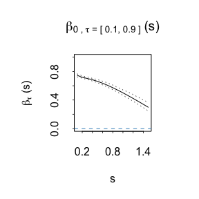

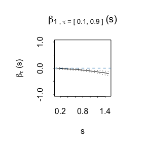

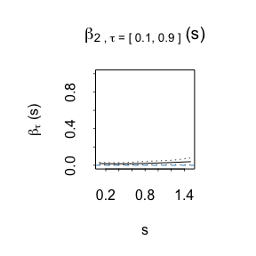

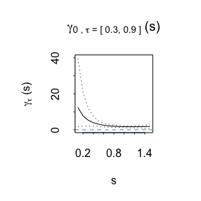

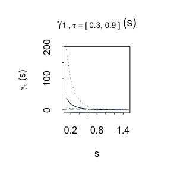

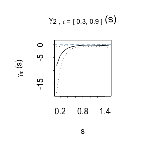

```r
res = lsurvROC(dat.long = example_data$data.long,
              dat.short = example_data$data.short,
              cutoff.type.basis = "FP",
              sens.type.basis = "FP",
              covariate1 = c("Z", "Zcont"),
              covariate2 = c("Z", "Zcont"),
              tau = seq(0.1, 0.9, 0.05),
              time.window = 1,
              monotone.method = "both",
              nResap = 50,
              newdata = data.frame(vtime = 0.5, Z = 1, Zcont = 0.25)
              )

plot(res, ROC = TRUE)
```